# TAE - Unit 6 - Recitation

GT

May 20, 2016

## Seeing the Big Picture

In this recitation, we will see how to apply clustering techniques to segment images, with the main application being geared towards medical image segmentation.

At the end of this recitation, you will get a head start on how to cluster an MRI brain image by tissue substances and locate pathological anatomies.

*Image segmentation* is the process of partitioning digital images into regions, or segments, that share the same visual characteristics, such as color, intensity, or texture.

The segments should also be meaningful, as in they should correspond to particular surfaces, objects, or even parts of an object.

Think of having an image of a water pond, a mountain chain in the backdrop, and the sky. Segmenting this image should ideally detect the three different objects and assign their corresponding pixels to three different regions.

In few words, the goal of image segmentation is to modify the representation of an image from pixel data into something meaningful to us and easier to analyze.

Image segmentation has a wide applicability.

A major practical application is in the field of medical imaging, where image segments often correspond to different tissues, organs, pathologies, or tumors.

Image segmentation helps locate these geometrically complex objects and measure their volume.

Another application is detecting instances of semantic objects such as humans, buildings, and others.

The two major domains that have seen much attention recently include face and pedestrian detection.

The main uses of facial detection, for instance, include the development of the auto-focus in digital cameras and face recognition commonly used in video surveillance.

Other important applications are fingerprint and iris recognition.

For instance, fingerprint recognition tries to identify print patterns, including aggregate characteristics of ridges and minutiae points.

In this recitation, we will look in particular at the medical imaging application.

Various methods have been proposed to segment images.

**Clustering methods** are used to group the points into clusters according to their characteristic features, for instance, intensity values. These clusters are then mapped back to the original spatial domain to produce a segmentation of the image.

Another technique is **Edge detection**, which is based on detecting discontinuities or boundaries. For instance, in a gray-scale image, a boundary would correspond to an abrupt change in the gray level.

Instead of finding boundaries of regions in the image, there are other techniques called **Region growing methods**, which start dividing the image into small regions. Then, they sequentially merge these regions together if they are sufficiently similar.

In this recitation, our focus is on clustering methods. In particular, we will review *hierarchical* and *k-means* clustering techniques and how to use them in R.

We will restrict ourselves to gray-scale images.

Our first example is a low-resolution flower image whose pixel intensity information is given the data set flower.csv.

Our second and major example involves two weighted MRI images of the brain. One image corresponds to a healthy patient, and the other one corresponds to a patient with a tumor called oligodendroglioma.

The pixel intensity information of these two images are given in the data sets healthy and tumor.csv.

The last video will compare the use, pros, and cons of all the analytics tools that we have seen so far.

I hope that this will help you synthesize all that you’ve learned to give you an edge in the class competition that is coming up soon.

### Clustering Pixels

Let us try to understand the format of the data handed to us in the CSV files.

Grayscale images are represented as a matrix of pixel intensity values that range from zero to one. The intensity value zero corresponds to the absence of color, or black, and the value one corresponds to white.

For 8 bits per pixel images, we have 256 color levels ranging from zero to one.

For instance, if we have the following grayscale image, the pixel information can be translated to a matrix of values between zero and one.

It is exactly this matrix that we are given in our datasets. In other words, the datasets contain a table of values between zero and one. And the number of columns corresponds to the width of the image, whereas the number of rows corresponds to the height of the image. For example, the resolution can be 7 by 7 pixels.

We have to be careful when reading the dataset in R. We need to make sure that R reads in the matrix appropriately. Until now in this class, our datasets were structured in a way where the rows refer to observations and the columns refer to variables. But this is not the case for the intensity matrix.

So keep in mind that we need to do some maneuvering to make sure that R recognizes the data as a matrix.

Grayscale image segmentation can be done by clustering pixels according to their intensity values. So we can think of our clustering algorithm as trying to divide the spectrum of intensity values from zero to one into intervals, or clusters.

For instance, the red cluster corresponds to the darkest shades, and the green cluster to the lightest.

Now, what should the input be to the clustering algorithm?

Well, our observations should be all of the 7 by 7 intensity values. Hence, we should have 49 observations. And we only have one variable, which is the pixel intensity value.

So in other words, the input to the clustering algorithm should be a vector containing 49 elements, or intensity values. But what we have is a 7 by 7 matrix.

A crucial step before feeding the intensity values to the clustering algorithm is morphing our data. We should modify the matrix structure and lump all the intensity values into a single vector.

Now, once we have the vector, we can simply feed it into the clustering algorithm and assign each element in the vector to a cluster.

Let us first use hierarchical clustering since we are familiar with it.

The first step is to calculate the distance matrix, which computes the pairwise distances among the elements of the intensity vector.

How many such distances do we need to calculate?

Well, for each element in the intensity vector, we need to calculate its distance from the other 48 elements. So this makes 48 calculations per element. And we have 49 such elements in the intensity vector.

In total, we should compute 49 times 48 pairwise distances. But due to symmetry, we really need to calculate half of them. So the number of pairwise distance calculations is actually $(49*48)/2$.

In general, if we call the size of the intensity vector n, then we need to compute
$$n*(n-1)/2$$
pairwise distances and store them in the distance matrix.

Now we should be ready to go to R.

```r
# read the matrix and save it to a data frame
flower = read.csv("flower.csv", header=FALSE) # by default R assumes that the first row is a header
str(flower)
```

```
## 'data.frame':    50 obs. of  50 variables:
##  $ V1 : num  0.0991 0.0991 0.1034 0.1034 0.1034 ...
##  $ V2 : num  0.112 0.108 0.112 0.116 0.108 ...
##  $ V3 : num  0.134 0.116 0.121 0.116 0.112 ...
##  $ V4 : num  0.138 0.138 0.121 0.121 0.112 ...
##  $ V5 : num  0.138 0.134 0.125 0.116 0.112 ...
##  $ V6 : num  0.138 0.129 0.121 0.108 0.112 ...
##  $ V7 : num  0.129 0.116 0.103 0.108 0.112 ...
##  $ V8 : num  0.116 0.103 0.103 0.103 0.116 ...
##  $ V9 : num  0.1121 0.0991 0.1078 0.1121 0.1164 ...
##  $ V10: num  0.121 0.108 0.112 0.116 0.125 ...
##  $ V11: num  0.134 0.125 0.129 0.134 0.129 ...
##  $ V12: num  0.147 0.134 0.138 0.129 0.138 ...
##  $ V13: num  0.000862 0.146552 0.142241 0.142241 0.133621 ...
##  $ V14: num  0.000862 0.000862 0.142241 0.133621 0.12931 ...
```

[output cut: 36 more lines]

We realize that the way the data is stored does not reflect that this is a matrix of intensity values. Actually, R treats the rows as observations and the columns as variables.

Let’s try to change the data type to a matrix by using the as.matrix function.

```r
flowerMatrix = as.matrix(flower)
str(flowerMatrix)
```

```
##  num [1:50, 1:50] 0.0991 0.0991 0.1034 0.1034 0.1034 ...
##  - attr(*, "dimnames")=List of 2
##   ..$ : NULL
##   ..$ : chr [1:50] "V1" "V2" "V3" "V4" ...
```

We realize that we have 50 rows and 50 columns. What this suggests is that the resolution of the image is 50 pixels in width and 50 pixels in height.

So let us define the vector flowerVector, and then now we’re going to use the function as.vector, which takes as an input the flowerMatrix.

```r
flowerVector = as.vector(flowerMatrix)
str(flowerVector)
```

```
##  num [1:2500] 0.0991 0.0991 0.1034 0.1034 0.1034 ...
```

We realize that we have 2,500 numerical values, which range between zero and one. And this totally makes sense because this reflects the 50 times 50 intensity values that we had in our matrix.

Now you might be wondering why we can’t immediately convert the data frame flower to a vector. Let’s try to do this.

```r
flowerVector2 = as.vector(flower)
str(flowerVector2)
```

```
## 'data.frame':    50 obs. of  50 variables:
##  $ V1 : num  0.0991 0.0991 0.1034 0.1034 0.1034 ...
##  $ V2 : num  0.112 0.108 0.112 0.116 0.108 ...
##  $ V3 : num  0.134 0.116 0.121 0.116 0.112 ...
##  $ V4 : num  0.138 0.138 0.121 0.121 0.112 ...
##  $ V5 : num  0.138 0.134 0.125 0.116 0.112 ...
##  $ V6 : num  0.138 0.129 0.121 0.108 0.112 ...
##  $ V7 : num  0.129 0.116 0.103 0.108 0.112 ...
##  $ V8 : num  0.116 0.103 0.103 0.103 0.116 ...
##  $ V9 : num  0.1121 0.0991 0.1078 0.1121 0.1164 ...
##  $ V10: num  0.121 0.108 0.112 0.116 0.125 ...
##  $ V11: num  0.134 0.125 0.129 0.134 0.129 ...
##  $ V12: num  0.147 0.134 0.138 0.129 0.138 ...
##  $ V13: num  0.000862 0.146552 0.142241 0.142241 0.133621 ...
##  $ V14: num  0.000862 0.000862 0.142241 0.133621 0.12931 ...
```

[output cut: 36 more lines]

It seems that R reads it exactly like the flower data frame and sees it as 50 observations and 50 variables. So converting the data to a matrix and then to the vector is a crucial step.

Now we should be ready to start our hierarchical clustering.

The first step is to create the distance matrix, as you already know, which in this case computes the difference between every two intensity values in our flower vector.

```r
distance = dist(flowerVector, method="euclidean")
```

### Hierarchical Clustering

Now we can cluster the intensity values using hierarchical clustering. As a reminder, the Ward’s method is a minimum variance method, which tries to find compact and spherical clusters. We can think about it as trying to minimize the variance within each cluster and the distance among clusters.

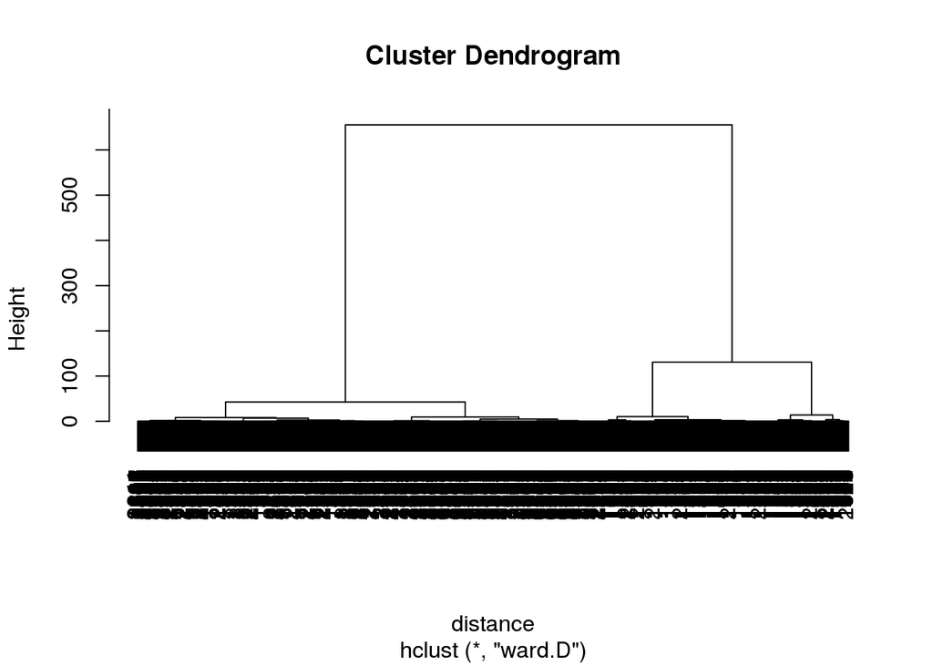

```r
clusterIntensity = hclust(distance, method = "ward.D")
plot(clusterIntensity)
```

And now we obtain the cluster dendrogram.

Let’s have here a little aside or a quick reminder about how to read a dendrogram and make sense of it. Let us first consider this toy dendrogram example.

```
              ABCDEF                                                          Level 5
+----------------------------------+
|                                  |
|                                  |
|              +------------------------------------------+
|              |                  BCDEF                   |                   Level 4
|              |                                          |
|              |                                          |
|              |                                          |
|              |                           +-------------------------+        Level 3
|              |                           |             DEF         |
|              |                           |                         |
|              |                           |                         |
|             BC                           DE                        |        Level 2
|        +----------+               +------------+                   |
|        |          |               |            |                   |
A        B          C               D            E                   F        Level 1
```

The lowest row of nodes represent the data or the individual observations, and the remaining nodes represent the clusters.

The vertical lines depict the distance between two nodes or clusters. The taller the line, the more dissimilar the clusters are.

For instance, cluster D-E-F is closer to cluster B-C-D-E-F than cluster B-C is. And this is well depicted by the height of the lines connecting each of clusters B-C and D-E-F to their parent node.

Now cutting the dendrogram at a given level yields a certain partitioning of the data.

For instance, if we cut the tree between levels two and three, we obtain four clusters, A, B-C, D-E, and F. If we cut the dendrogram between levels three and four, then we obtain three clusters, A, B-C, and D-E-F. And if we were to cut the dendrogram between levels four and five, then we obtain two clusters, A and B-C-D-E-F.

What to choose, two, three, or four clusters?

Well, the smaller the number of clusters, the coarser the clustering is. But at the same time, having many clusters may be too much of a stretch. We should always have this trade-off in mind.

Now the distance information between clusters can guide our choice of the number of clusters. A good partition belongs to a cut that has a good enough room to move up and down. For instance, the cut between levels two and three can go up until it reaches cluster D-E-F. The cut between levels three and four has more room to move until it reaches the cluster B-C-D-E-F. And the cut between levels four and five has the least room.

So it seems like choosing three clusters is reasonable in this case.

Going back to our dendrogram, it seems that having two clusters or three clusters is reasonable in our case.

We can actually visualize the cuts by plotting rectangles around the clusters on this tree.

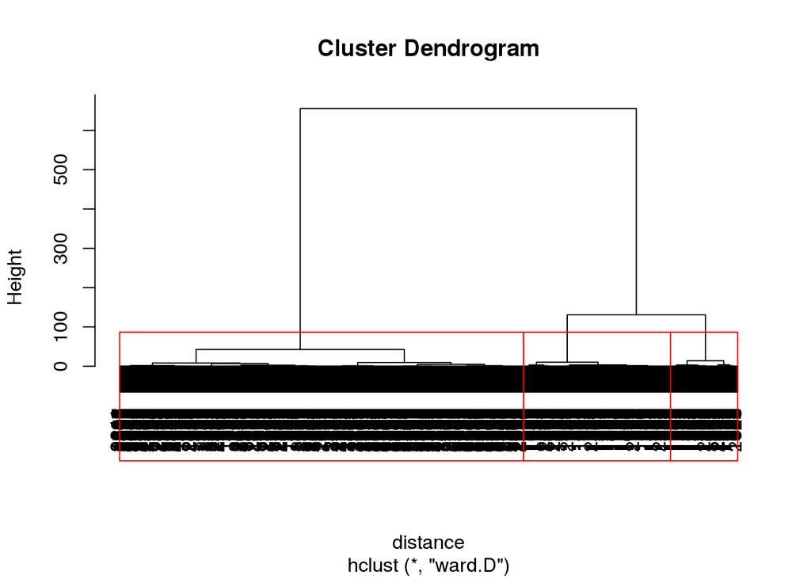

```r
plot(clusterIntensity)
rect.hclust(clusterIntensity, k=3, border="red")
```

Now we can see the three clusters in these red rectangles. Now let us split the data into these three clusters.

```r
flowerClusters = cutree(clusterIntensity, k=3) # to have three clusters
length(flowerClusters)
```

```
## [1] 2500
```

```r
flowerClusters[400:600]
```

```
##   [1] 1 1 1 1 1 1 1 1 1 1 1 1 1 1 1 1 1 1 2 2 1 1 1 3 3 3 3 3 2 1 2 3 2 1 1
##  [36] 1 1 1 1 1 1 1 1 1 1 1 1 1 1 1 1 1 1 1 1 1 1 1 1 1 1 1 1 1 1 1 1 1 3 3
##  [71] 1 1 1 3 3 3 3 3 2 2 3 3 1 1 1 1 1 1 1 1 1 1 1 1 1 1 1 1 1 1 1 1 1 1 1
## [106] 1 1 1 1 1 1 1 1 1 1 1 1 2 3 3 2 1 1 3 3 3 3 3 2 3 3 3 1 2 3 3 1 1 1 1
## [141] 1 1 1 1 1 1 1 1 1 1 1 1 1 1 1 1 1 1 1 1 1 1 1 2 3 2 1 2 3 3 3 1 1 3 3
## [176] 3 3 3 2 3 3 2 2 3 3 2 2 2 2 1 1 1 1 1 1 1 1 1 1 1 1
```

We see that flowerClusters is actually a vector that assigns each intensity value in the flower vector to a cluster. It actually has the same length, which is 2,500, and has values 1, 2, and 3, which correspond to each cluster.

To find the mean intensity value of each of our clusters, we can use the tapply function and ask R to group the values in the flower vector according to the flower clusters, and then apply the mean statistic to each of the groups.

```r
tapply(flowerVector, flowerClusters, mean)
```

```
##          1          2          3
## 0.08574315 0.50826255 0.93147713
```

And now the fun part. Let us see how the image was segmented. To output an image, we can use the image function in R, which takes a matrix as an input. But the variable flowerClusters, as we just saw, is a vector. So we need to convert it into a matrix. We can do this by setting the dimension of this variable by using the dimension function.

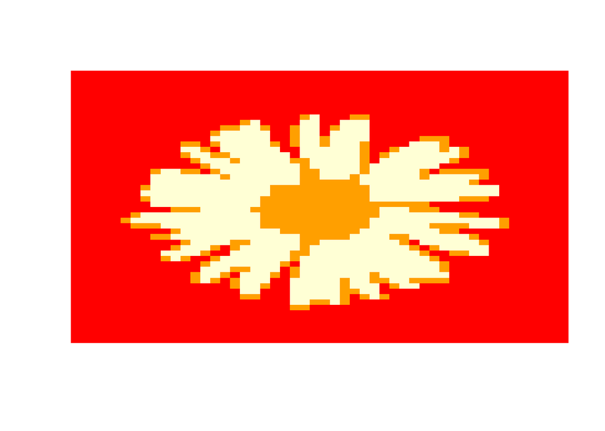

```r
dim(flowerClusters) = c(50, 50)
image(flowerClusters, axes=FALSE)
```

The darkest shade corresponds to the background, and this is actually associated with the first cluster. The one in the middle is the core of the flower, and this is cluster 2. And then the petals correspond to cluster 3, which has the fairest shade in our image.

Let us now check how the original image looked.

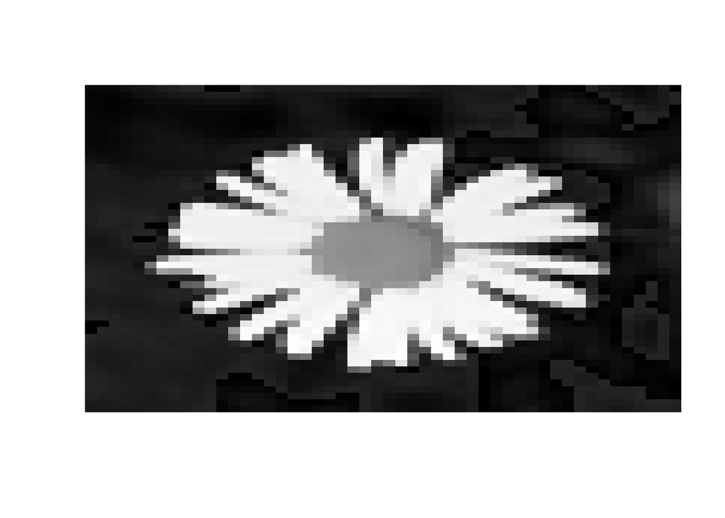

```r
image(flowerMatrix, axes=FALSE, col = grey(seq(0,1,length=256)))
```

Now we can see our original grayscale image here. You can see that it has a very, very low resolution.

### MRI Image

In this lecture we will try to segment an MRI brain image of a healthy patient using hierarchical clustering.

We will be following the exact same steps we did in the previously.

First, read in the data, and call the data frame healthy.

```r
healthy = read.csv("healthy.csv", header = FALSE)
healthyMatrix = as.matrix(healthy)
str(healthyMatrix)
```

```
##  num [1:566, 1:646] 0.00427 0.00855 0.01282 0.01282 0.01282 ...
##  - attr(*, "dimnames")=List of 2
##   ..$ : NULL
##   ..$ : chr [1:646] "V1" "V2" "V3" "V4" ...
```

Then we realize that we have 566 by 646 pixel resolution for our image. So this MRI image is considerably larger than the little flower image that we saw, and we worked with previously.

To see the MRI image, we can use the image function in R, which takes as an input the healthy matrix.

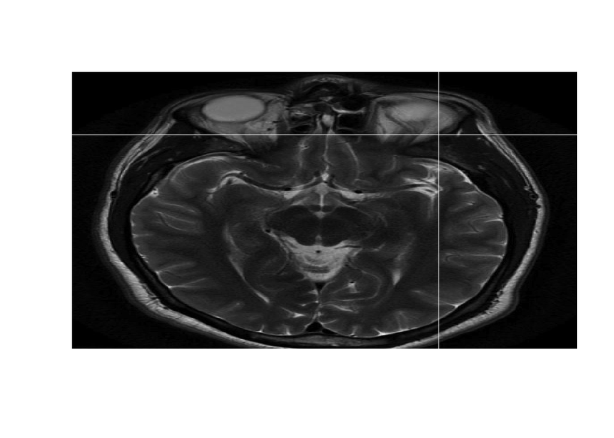

```r
image(healthyMatrix, axes=FALSE, col = grey(seq(0,1,length=256)))
```

And now we see that what we have is the T2-weighted MRI imaging of a top section of the brain. And it shows different substances, such as the gray matter, the white matter, and the cerebrospinal fluid.

Now let us see if we can isolate these substances via hierarchical clustering.

We first need to convert the healthy matrix to a vector, and let’s call it healthyVector.

```r
healthyVector = as.vector(healthyMatrix)
```

And now the first step in performing hierarchical clustering is computing the distance matrix.

`distance = dist(healthyVector, method="euclidean")`

`Error: cannot allocate vector of size 2.0 Gb

R gives us an error that seems to tell us that our vector is huge, and R cannot allocate enough memory.

Well let us see how big is our vector. So we’re going to go and use the structure function over the healthy vector,and let’s see what we obtain.

```r
str(healthyVector)
```

```
##  num [1:365636] 0.00427 0.00855 0.01282 0.01282 0.01282 ...
```

The healthy vector has 365,636 elements.

And remember, from our previous video, that for R to calculate the pairwise distances, it would actually need to calculate
$$\frac{n*(n-1)}{2}$$
and then store them in the distance matrix.

Let’s see how big this number is.

```r
n = 365636
n*(n-1)/2
```

```
## [1] 66844659430
```

Wow. Of course R would complain. It’s 67 billion values that we’re asking R to store in a matrix. The bad news now is that we cannot use hierarchical clustering.

Is there any other solution?

Well, we have seen in lecture two that another clustering method is k-means.

Let us review it first, and see if it could work on our high resolution image.

The k-means clustering algorithm aims at partitioning the data into k clusters, in a way that each data point belongs to the cluster whose mean is the nearest to it.

Let’s go over the algorithm step-by-step.

k-Means Clustering Algorithm

1. Specify desidered number of clusters k
2. Randomly assign each data point to cluster
3. Compute cluster centroids
4. Re-assign each point to the closest cluster centroid
5. Re-compute cluster centroids
6. Repeate 4 and 5 until no improvement is made

In this example we have five data points.

The first step is to specify the number of clusters. And suppose we wish to find two clusters, so set k=2. Then we start by randomly grouping the data into two clusters. For instance, three points in the red cluster, and the remaining two points in the grey cluster.

The next step is to compute the cluster means or centroids. Let’s first compute the mean of the red cluster, and then the mean of the grey cluster is simply the midpoint.

Now remember that the k-means clustering algorithm tries to cluster points according to the nearest mean. But this red point over here seems to be closer to the mean of the grey cluster, then to the mean of the red cluster to which it was assigned in the previous step.

So intuitively, the next step in the k-means algorithm is to re-assign the data points to the closest cluster mean. As a result, now this red point should be in the grey cluster.

Now that we moved one point from the red cluster over to the grey cluster, we need to update the means. This is exactly the next step in the k-means algorithm. So let’s recompute the mean of the red cluster, and then re-compute the mean of the grey cluster.

Now we go back to Step 4. Is there any point here that seems to be cluster to a cluster mean that it does not belong to? If so, we need to re-assign it to the other cluster. However, in this case, all points are closest to their cluster mean, so the algorithm is done, and we can stop.

### K-Means Clustering

The first step in k-means clustering involves specifying the number of clusters, k.

*But how do we select k?*

Well, our clusters would ideally assign each point in the image to a tissue class or a particular substance, for instance, grey matter or white matter, and so on. And these substances are known to the medical community. So setting the number of clusters depends on exactly what you’re trying to extract from the image.

For the sake of our example, let’s set the number of clusters here, k, to five. And since the k-means clustering algorithm starts by randomly assigning points to clusters, we should set the seed, so that we all obtain the same clusters.

```r
k=5
set.seed(1)
```

To run the k-means clustering algorithm, or KMC in short, we need to use the kmeans function in R. And the first input is whatever we are trying to cluster. The second argument is the number of clusters, Since the k-means is an iterative method that could take very long to converge, we need to set a maximum number of iterations.

```r
KMC = kmeans(healthyVector, centers=k, iter.max=1000)
```

The k-means algorithm is actually quite fast, even though we have a high resolution image. Now to see the result of the k-means clustering algorithm, we can output the structure of the KMC variable.

```r
str(KMC)
```

```
## List of 9
##  $ cluster     : int [1:365636] 3 3 3 3 3 3 3 3 3 3 ...
##  $ centers     : num [1:5, 1] 0.4818 0.1062 0.0196 0.3094 0.1842
##   ..- attr(*, "dimnames")=List of 2
##   .. ..$ : chr [1:5] "1" "2" "3" "4" ...
##   .. ..$ : NULL
##  $ totss       : num 5775
##  $ withinss    : num [1:5] 96.6 47.2 39.2 57.5 62.3
##  $ tot.withinss: num 303
##  $ betweenss   : num 5472
##  $ size        : int [1:5] 20556 101085 133162 31555 79278
##  $ iter        : int 2
##  $ ifault      : int 0
##  - attr(*, "class")= chr "kmeans"
```

The first, and most important, piece of information that we get, is the cluster vector. Which assigns each intensity value in the healthy vector to a cluster. In this case, it will be giving them values 1 through 5, since we have 5 clusters. Now recall that to output the segmented image, we need to extract this vector.

```r
healthyClusters = KMC$cluster
```

Now how can we obtain the mean intensity value within each of our 5 clusters?

In hierarchical clustering, we needed to do some manual work, and use the tapply function to extract this information. In this case, we have the answers ready, under the vector centers. In fact, for instance, the mean intensity value of the first cluster is 0.48, and the mean intensity value of the last cluster is 0.18.

Before we move on, I would like to point your attention to one last interesting piece of information that we can get here. And that is the size of the cluster. For instance, the largest cluster that we have is the third one, which combines 133,000 values in it. And interestingly, it’s the one that has the smallest mean intensity value, which means that it corresponds to the darkest shade in our image.

Actually, if we look at all the mean intensity values, we can see that they are all less than 0.5. So they’re all pretty close to 0. And this means that our images is pretty dark.

Now the exciting part. Let us output the segmented image and see what we get.

Recall that we first need to convert the vector healthy clusters to a matrix.

To do this, we will use the dimension function, that takes as an input the healthyClusters vector. And now we’re going to turn it into a matrix. So we have to specify using the combine function, the number of rows, and the number of columns that we want. We should make sure that it corresponds to the same size as the healthy matrix. And since we’ve forgot the number of rows and the number columns in the healthy matrix, we can simply use the nrow and ncol function to get them. We’re going to invoke for color here, the rainbow palette in R. And the rainbow palette, or the function rainbow, takes as an input the number of colors that we want. In this case, the number of colors would correspond to the number of clusters. So the input would be k.

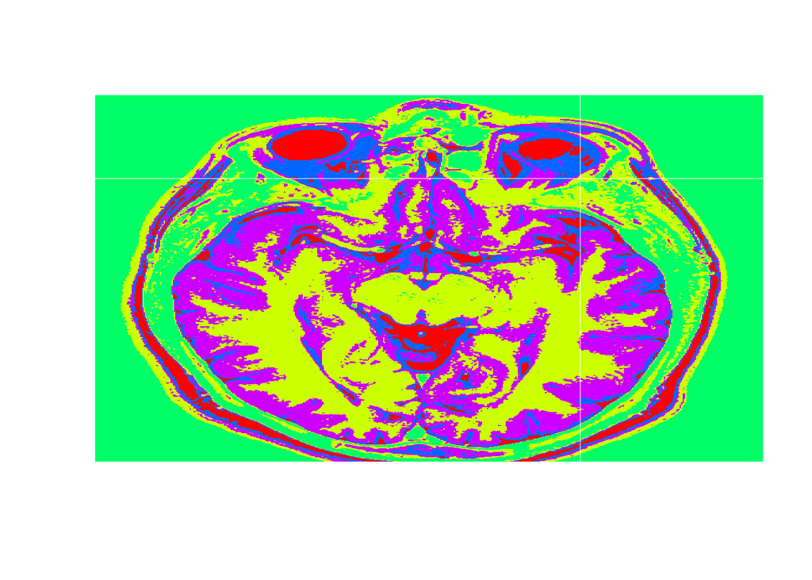

```r
dim(healthyClusters) = c(nrow(healthyMatrix),ncol(healthyMatrix))
image(healthyClusters, axes=FALSE, col = rainbow(k))
```

More refinement maybe needs to be made to our clustering algorithm to appropriately capture all the anatomical structures. But this seems like a good starting point.

The question now is, can we use the clusters, or the classes, found by our k-means algorithm on the healthy MRI image to identify tumors in another MRI image of a sick patient?

### Detecting Tumors

It would be really helpful if we can use these clusters to automatically detect tumors in MRI images of sick patients.

The tumor.csv file corresponds to an MRI brain image of a patient with oligodendroglioma, a tumor that commonly occurs in the front lobe of the brain. Since brain biopsy is the only definite diagnosis of this tumor, MRI guidance is key in determining its location and geometry.

Let’s read the data, and save it to a data frame that we’re going to call tumor, and use the read.csv function, which takes as an input the tumor dataset, and make sure to turn off the header using header equals FALSE.

```r
tumor = read.csv("tumor.csv", header=FALSE)
```

And let’s quickly create our tumorMatrix, using the as.matrix function over the tumor data frame, and the tumorVector, using the as.vector function over the tumorMatrix.

```r
tumorMatrix = as.matrix(tumor)
tumorVector = as.vector(tumorMatrix)
```

Now, we will not run the k-means algorithm again on the tumor vector. Instead, we will apply the k-means clustering results that we found using the healthy brain image on the tumor vector. In other words, we treat the healthy vector as training set and the tumor vector as a testing set.

To do this, we first need to use a new package that is called flexclust, then load it by typing library(flexclust). The flexclust package contains the object class KCCA, which stands for K-Centroids Cluster Analysis.

```r
library(flexclust)
```

We need to convert the information from the clustering algorithm to an object of the class KCCA. And this conversion is needed before we can use the predict function on the test set tumorVector.

The as.kcca function, which takes as a first input the original KMC variable that stored all the information from the k-means clustering function, and the second input is the data that we clustered. And in this case, it’s the training set, which is the healthyVector.

```r
KMC.kcca = as.kcca(KMC, healthyVector)
```

Now that R finally finished creating the object KMC.kcca, we can cluster the pixels in the tumorVector using the predict function.

```r
tumorClusters = predict(KMC.kcca, newdata=tumorVector)
```

And now, the tumorClusters is a vector that assigns a value 1 through 5 to each of the intensity values in the tumorVector, as predicted by the k-means algorithm.

To output the segmented image, we first need to convert the tumor clusters to a matrix.

```r
dim(tumorClusters) = c(nrow(tumorMatrix), ncol(tumorMatrix))
```

And now, we can visualize the clusters by using the image function with the input tumorClusters matrix, and make sure to set the axes to FALSE, and let’s use again these fancy rainbow colors, here.

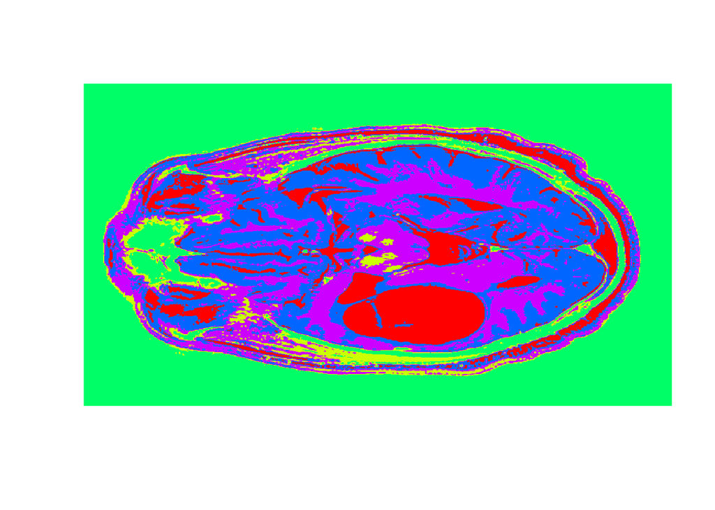

```r
image(tumorClusters, axes=FALSE, col=rainbow(k))
```

Let’s navigate to the graphics window, now, to see if we can detect the tumor. Oh, and yes, we do! It is this abnormal substance here that is highlighted in “blue” (red) that was not present in the healthy MRI image.

So we were successfully able to identify, more or less, the geometry of the malignant structure. We see that we did a good job capturing the major tissue substances of the brain.

Actually, looking at the eyes regions, we notice that the two images were not taken precisely at the same section of the brain. This might explain some differences in shapes between the two images.

Let’s see how the images look like originally.

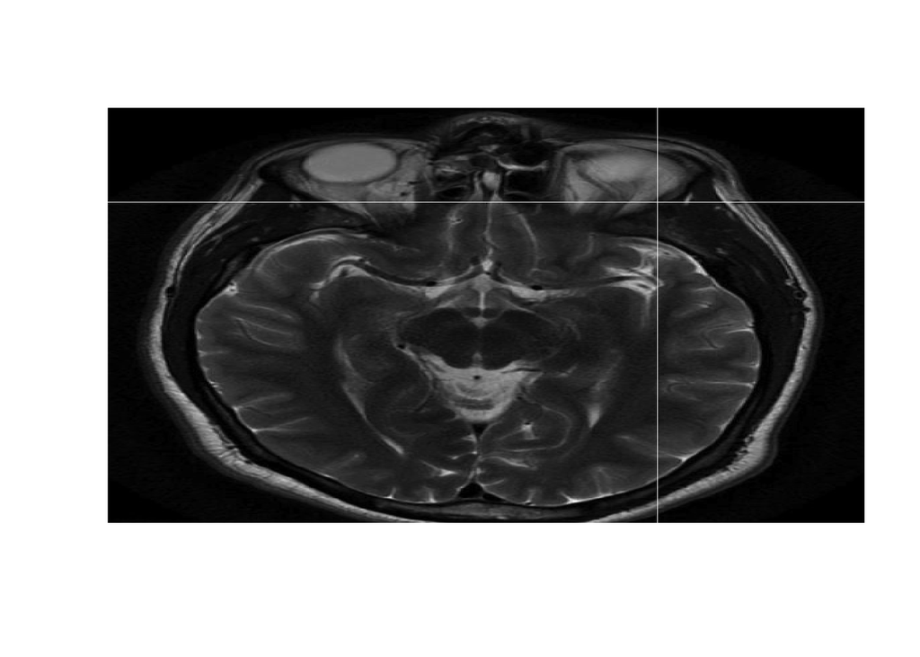

```r
image(healthyMatrix, axes=FALSE, col = grey(seq(0,1,length=256)))
```

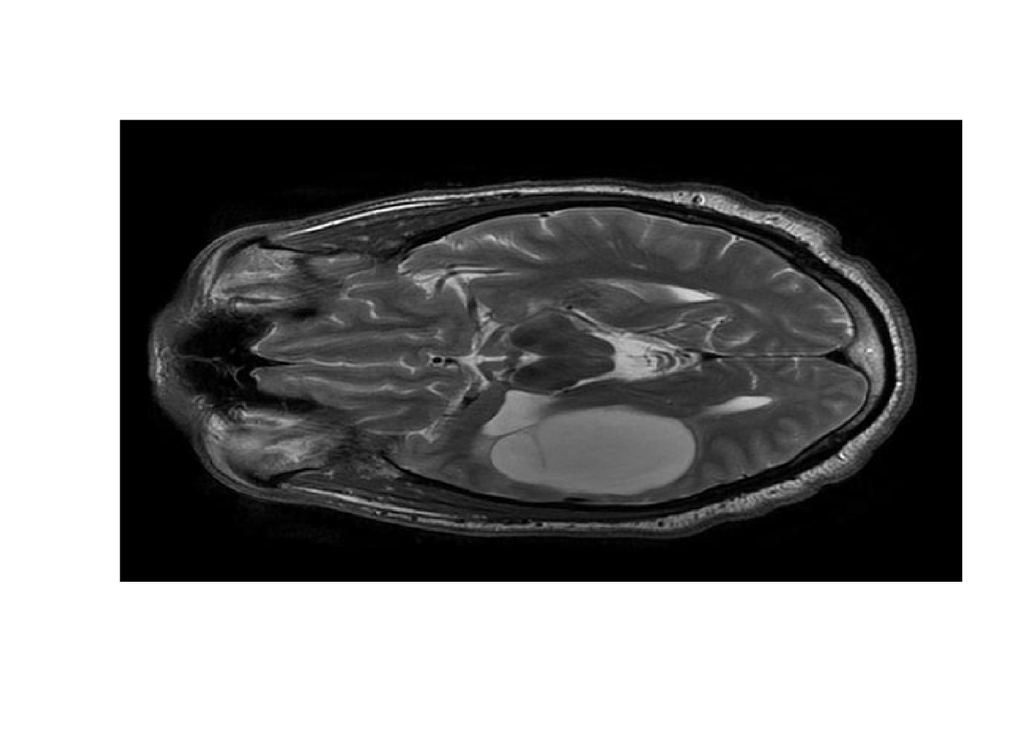

```r
image(tumorMatrix, axes=FALSE, col = grey(seq(0,1,length=256)))
```

We see that the tumor region has a lighter color intensity, which is very similar to the region around the eyes in the healthy brain image.

Of course, we cannot claim that we did a wonderful job obtaining the exact geometries of all the tissue substances, but we are definitely on the right track. In fact, to do so, we need to use more advanced algorithms and fine-tune our clustering technique.

MRI image segmentation is an ongoing field of research. While k-means clustering is a good starting point, more advanced techniques have been proposed in the literature, such as the modified fuzzy k-means clustering method.

Also, if you are interested, R has packages that are specialized for analyzing medical images. Now, if we had MRI axial images taken at different sections of the brain, we could segment each image and capture the geometries of the substances at different levels.

Then, by interpolating between the segmented images, we can estimate the missing slices, and we can then obtain a 3D reconstruction of the anatomy of the brain from 2D MRI cross-sections.

In fact, 3D reconstruction is particularly important in the medical field for diagnosis, surgical planning, and biological research purposes.

### Comparing Methods

```
           | Used For                 | Pros                 | Cons
-----------+--------------------------+----------------------+---------------------
Linear     | Predicting a continous   | - Simple, well       | - Assumes a linear
Regression | outcome (salary, price,  |   recognized         |   relationship
           | number of votes, etc.)   | - Works on small     |   Y = a log(X)+b
           |                          |   and large datasets |
-----------+--------------------------+----------------------+---------------------
Logistic   | Predicting a categorical | - Computes           | - Assumes a linear
Regression | outcome (Yes/No,         |   probabilities that |   relationship
           | Sell/Buy,                |   can be used to     |
           | Accept, Reject, etc.)    |   assess confidence  |
           |                          |   of the prediction  |
-----------+--------------------------+----------------------+---------------------
CART       | Predicting a categorical | - Can handle         | - May not work
           | outcome (quality rating  |   datasets without   |   well with small
           | 1--5, Buy/Sell/Hold) or  |   a linear           |   datasets
           | a continous outcome      |   relationship       |
           | (salary, price, etc.)    | - Easy to explain    |
           |                          |   and interpret      |
-----------+--------------------------+----------------------+---------------------
Random     | Same as CART             | - Can improve        | - Many parameters
Forest     |                          |   accuracy over      |   to adjust
           |                          |   CART               | - Not as easy to
           |                          |                      |   explain as CART
-----------+--------------------------+----------------------+---------------------
Hierachic- | - Find similar           | - No need to select  | - Hard to use with
al         |   groups                 |   number of clusters |   large datasets
Clustering | - Clustering into        |   a priori           |
           |   smaller groups and     | - Visualize with a   |
           |   applying predictive    |   dendrogram         |
           |   methods on groups      |                      |
-----------+--------------------------+----------------------+---------------------
k-means    | Same as Hierarchical     | - Works with any     | - Need to select
Clustering | Clustering               |   dataset size       |   number of
           |                          |                      |   cluster before
           |                          |                      |   algorithm
```